# Waste Management, Inc. (NYSE: WM) — Proyecto Final

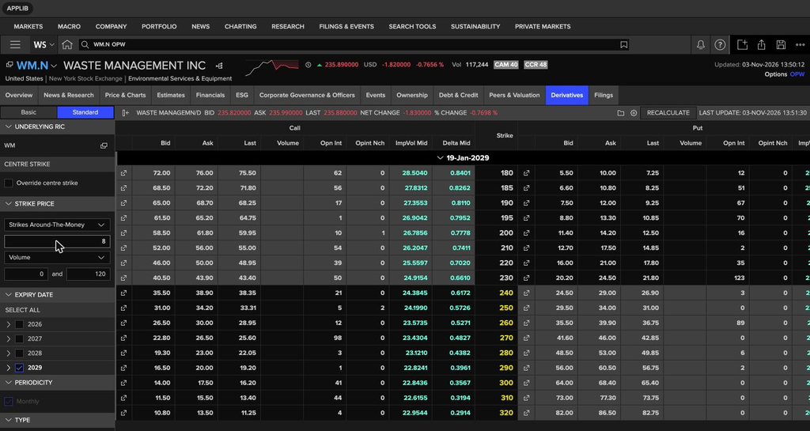

**LSEG US5YT=RR: Treasury a 5 años (03-nov-2026)**

[figure not shown]

**LSEG US7YT=RR: Treasury a 7 años (03-nov-2026)**

[figure not shown]

**LSEG Rates View: curva Treasury, swap spreads, OIS y futuros con CTD (03-nov-2026)**

[figure not shown]

**LSEG Rates View: detalle de benchmarks, swap spreads y futuros TU/FV/TY/TN/US (03-nov-2026)**

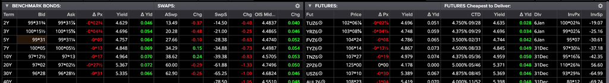

**LSEG CAD=: tipo de cambio USD/CAD 1.4122/1.4126 (06-nov-2026 15:22), swap de divisas**

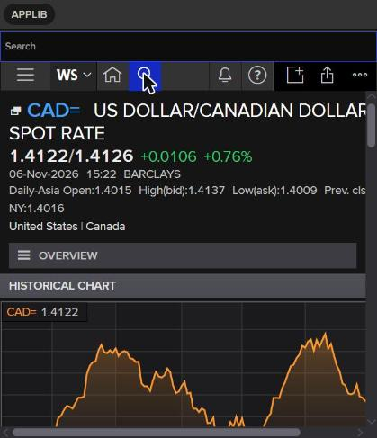

**LSEG REPS: bono del Gobierno de Canadá 3.00% 2031, rendimiento 3.374% (benchmark 5 años, 05-nov-2026)**

[figure not shown]

**LSEG: bono WM 3.944% 15-jul-2033 en CAD (CA94107TAB76), C$ 700 mm, cupón semestral**

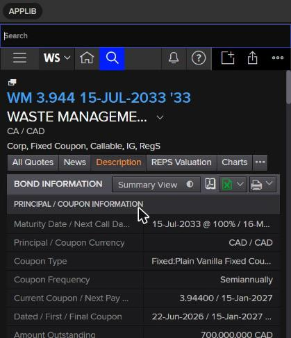

**LSEG REPS: bono WM 3.944% 2033, YTM 4.186%, 78 pb sobre la curva de Canadá a 6.69 años (3.40%)**

[figure not shown]

**LSEG REPS: bono Apple 4.500% 12-may-2032, YTM 4.905%, 27 pb sobre el Treasury (05-nov-2026), referencia AA**

[figure not shown]

**LSEG Key Ratios: Republic Services (RSG.N), 28-oct-2026**

[figure not shown]

**LSEG Key Ratios: Waste Connections (WCN.N), 28-oct-2026**

[figure not shown]

**Colab: parámetros GARCH(1,1) de WM y RSG**

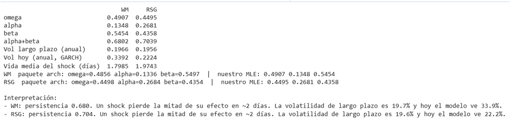

**Colab: volatilidad histórica, EWMA y GARCH**

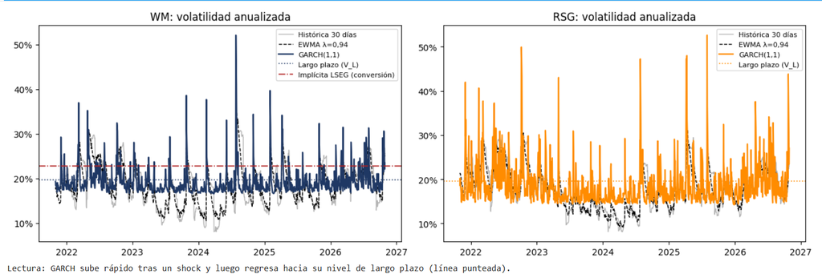

**Colab: estructura temporal de la volatilidad**

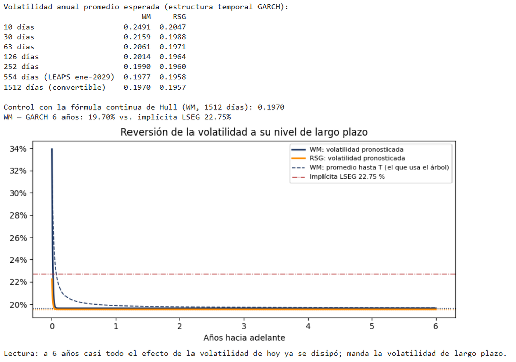

**Colab: back testing del VaR (Kupiec)**

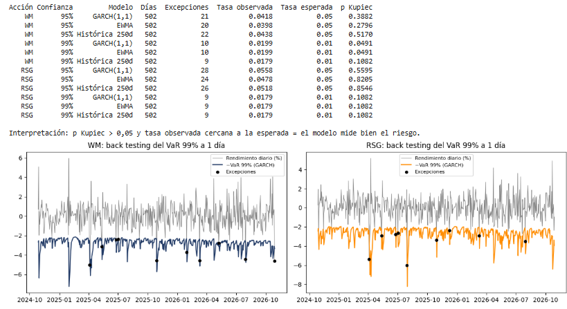

**Colab: cupón a la par por volatilidad**

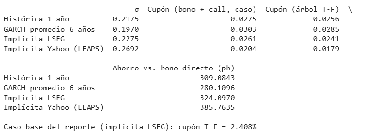

**Colab: dilución y señal de emisión**

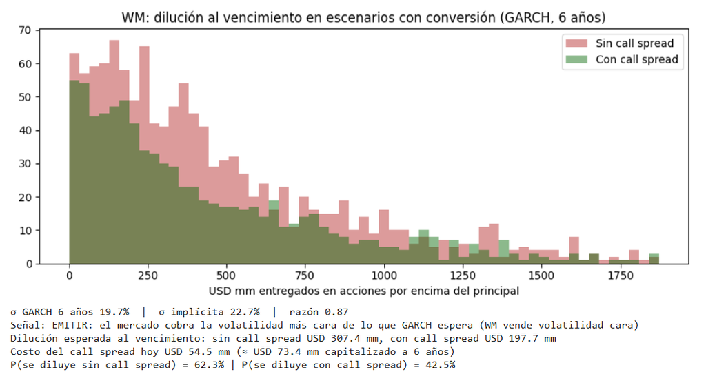

**Alpaca (paper): orden multi-pierna limitada enviada el 03-nov-2026, estado “new”; expiró sin ejecutarse**

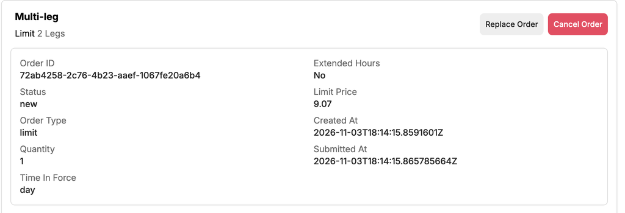

**Alpaca (paper): piernas de la orden, compra call 290 y venta call 340, vencimiento 19-ene-2029**

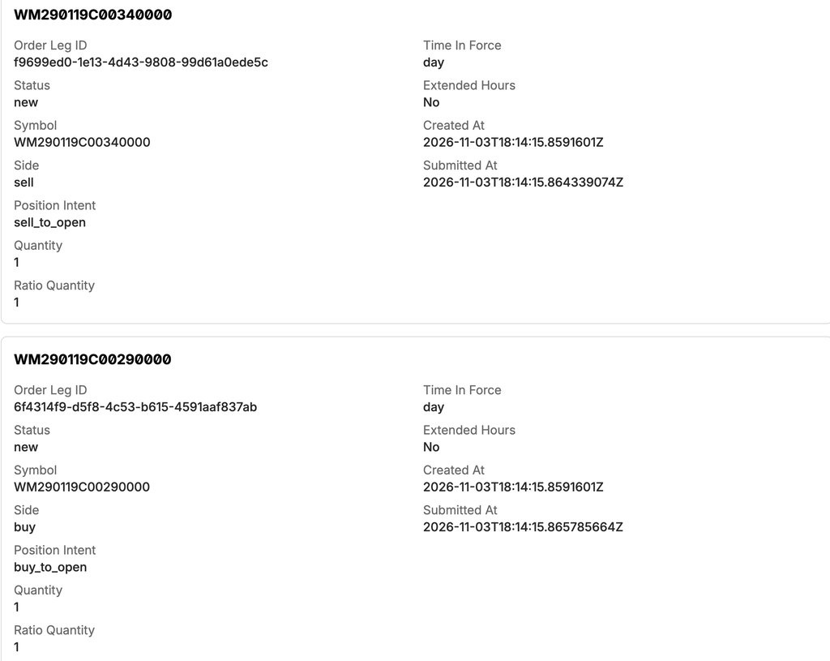

# Uso de inteligencia artificial

Se usó Claude (Anthropic) para revisar la coherencia entre el notebook, el reporte y el dashboard, recalcular de forma independiente el motor de valuación (cupón, call spread, recompra y métricas de crédito), ejecutar el notebook de Colab de principio a fin, tomar en el navegador del equipo las capturas de LSEG del 03-nov-2026 y corregir la redacción. Los datos, los modelos y las decisiones del análisis son del equipo; los cálculos del motor no se modificaron.

# Anexo B. Código del motor de valuación

```r
# =====================================================================
# MOTOR DE VALUACIÓN (el código completo se muestra en el Anexo B)
# =====================================================================
# ---- Insumos de mercado (LSEG Workspace, 21-oct-2026) ----
precio <- 229.58                       # cierre oficial WM
mktcap <- 91767                        # USD mm
acciones <- mktcap / precio            # mm de acciones
ust5 <- 0.049182; ust7 <- 0.049954     # Treasuries 5 y 7 años
rf   <- (ust5 + ust7) / 2              # libre de riesgo 6 años (interpolada)
y_wm <- 0.05649                        # YTM curva WM a 6 años (Issuer Curve)
q    <- 0.0163                         # dividend yield bruto
s_c  <- 0.227453                       # vol. implícita strike 290 (≈ precio de conversión)
s_w  <- 0.2104                         # vol. histórica 90d (para el warrant, como el caso)

# ---- Términos propuestos ----
monto <- 750; Tm <- 6; F <- 1000
prima_conv <- 0.25; prima_warr <- 0.60
K  <- precio * (1 + prima_conv); n <- F / K; Kw <- precio * (1 + prima_warr)
acc_mm <- monto / K                    # mm de acciones subyacentes del convertible

# ---- Funciones ----
bs_call <- function(S, K, r, s, T, q = 0) {
  d1 <- (log(S / K) + (r - q + s^2 / 2) * T) / (s * sqrt(T)); d2 <- d1 - s * sqrt(T)
  c(precio = S * exp(-q * T) * pnorm(d1) - K * exp(-r * T) * pnorm(d2),
    delta  = exp(-q * T) * pnorm(d1),
    gamma  = exp(-q * T) * dnorm(d1) / (S * s * sqrt(T)),
    vega   = S * exp(-q * T) * dnorm(d1) * sqrt(T) / 100)          # por 1 punto de vol
}
valor_bono <- function(cup, y = y_wm, F = 1000, T = 6, m = 2) {
  t <- 1:(T * m); cf <- rep(F * cup / m, T * m); cf[T * m] <- cf[T * m] + F
  sum(cf / (1 + y / m)^t)
}
# Árbol binomial CRR (europea o americana) con dividend yield continuo
crr_call <- function(S, K, r, s, T, N, q = 0, americana = FALSE) {
  dt <- T / N; u <- exp(s * sqrt(dt)); d <- 1 / u
  p <- (exp((r - q) * dt) - d) / (u - d); desc <- exp(-r * dt)
  j <- 0:N; V <- pmax(S * u^(N - j) * d^j - K, 0)
  for (i in (N - 1):0) {
    V <- desc * (p * V[1:(i + 1)] + (1 - p) * V[2:(i + 2)])
    if (americana) { j <- 0:i; V <- pmax(V, S * u^(i - j) * d^j - K) }
  }
  V[1]
}
# Convertible completo en árbol: método Tsiveriotis-Fernandes (1998)
#  - componente "efectivo" (cupones y principal) se descuenta a la tasa de WM (riesgo de crédito)
#  - componente "acciones" se descuenta a la libre de riesgo
#  - en cada nodo el tenedor convierte si n*S > valor de continuar (conversión anticipada)
tf_convertible <- function(cup, S = precio, prima = prima_conv, s = s_c, qd = q, N = 360,
                           T = Tm, F = 1000, r = rf, y = y_wm) {
  nn <- F / (S * (1 + prima)); dt <- T / N
  u <- exp(s * sqrt(dt)); d <- 1 / u; p <- (exp((r - qd) * dt) - d) / (u - d)
  rc <- 2 * log(1 + y / 2)                      # YTM semestral -> tasa continua
  dr <- exp(-r * dt); dk <- exp(-rc * dt)
  paso <- N / (2 * T); cpn <- F * cup / 2       # cupón semestral cada 'paso' nodos
  j <- 0:N; conv <- nn * S * u^(N - j) * d^j
  V <- pmax(conv, F + cpn); B <- ifelse(conv >= F + cpn, 0, F + cpn)
  for (i in (N - 1):0) {
    a <- 1:(i + 1); b <- 2:(i + 2)
    Bc <- dk * (p * B[a] + (1 - p) * B[b])
    Ec <- dr * (p * (V[a] - B[a]) + (1 - p) * (V[b] - B[b]))
    if (i > 0 && i %% paso == 0) Bc <- Bc + cpn
    Vc <- Bc + Ec; j <- 0:i; cv <- nn * S * u^(i - j) * d^j
    convierte <- cv > Vc
    V <- ifelse(convierte, cv, Vc); B <- ifelse(convierte, 0, Bc)
  }
  V[1]
}
cupon_par_tf <- function(...) uniroot(function(cc) tf_convertible(cc, ...) - 1000,
                                      c(-0.03, 0.10), extendInt = "yes", tol = 1e-10)$root

# ---- Resultados base ----
# (a) Avance: Black-Scholes sin dividendo
call0   <- bs_call(precio, K, rf, s_c, Tm)
opcion0 <- call0["precio"] * n
cupon0  <- uniroot(function(c) valor_bono(c) - (1000 - opcion0), c(-0.05, 0.1), tol = 1e-12)$root
hedge0  <- call0["precio"] * acc_mm
warr0   <- bs_call(precio, Kw, rf, s_w, Tm)["precio"] * acc_mm
# (b) Final: Black-Scholes con dividendo
callq   <- bs_call(precio, K, rf, s_c, Tm, q)
opcionq <- callq["precio"] * n
cuponq  <- uniroot(function(c) valor_bono(c) - (1000 - opcionq), c(-0.05, 0.1), tol = 1e-12)$root
# (c) Final: convertible completo en árbol (caso base de la recomendación)
cupon_tf <- cupon_par_tf()
# Call spread con dividendo
warr_c  <- bs_call(precio, Kw, rf, s_w, Tm, q)
hedge   <- callq["precio"] * acc_mm
warr    <- warr_c["precio"] * acc_mm
neto_cs <- hedge - warr

# ---- La operación para WM ----
recompra <- data.frame(
  Bono = c("WM 7.00% 15-jul-2028", "WM 7.75% 15-may-2032", "WM 6.125% 30-nov-2039"),
  ISIN = c("US902917AH67", "US94106LAN91", "US94106LAV18"),
  Cupon = c(0.07, 0.0775, 0.06125),
  Nominal_mm = c(257.907, 143.621, 245.686),
  Precio_ask = c(102.8405, 108.8381, 102.2998),
  Prima_tender = 1
)
recompra$Costo_tender_mm <- recompra$Nominal_mm * (recompra$Precio_ask + recompra$Prima_tender) / 100
recompra$Cupon_anual_mm  <- recompra$Nominal_mm * recompra$Cupon
comision   <- 0.02                       # supuesto: comisión de colocación 2% (rango usual 1.5-2.5%)
tasa_imp   <- 0.21                       # supuesto: tasa federal de EE.UU.
tender     <- sum(recompra$Costo_tender_mm)
cup_elim   <- sum(recompra$Cupon_anual_mm)
cup_nuevo  <- monto * cupon_tf
ahorro     <- cup_elim - cup_nuevo
remanente  <- monto * (1 - comision) - tender - neto_cs
```

Fuentes: LSEG Workspace (Refinitiv) — Overview, Price Performance, Key Ratios, Debt Structure, Issuer Curve, Issuer Ratings, Options (OPW), US5YT=RR, US7YT=RR; Yahoo Finance (precios diarios para GARCH); Alpaca (paper trading); caso “Molson Coors Brewing Co.: Valuing a Convertible Bond” (Tec de Monterrey, NE90-06-107); Hull, *Options, Futures and Other Derivatives*, cap. 23 “Estimating Volatilities and Correlations”; Tsiveriotis y Fernandes (1998), “Valuing Convertible Bonds with Credit Risk”, *Journal of Fixed Income*. Datos al cierre del 21-oct-2026.